# 如何优雅的成为知乎大V

狗熊会

案例难度：**

案例背景： 知乎是中文互联网最大的知识平台，也是目前国内最有名的知识问答社区。截至2018年5月，知乎网站已拥有1.6亿注册用户。在知乎社区里，那些拥有众多关注者，有很大影响力的知乎用户，被称之为知乎大V。在信息爆炸、知识碎片化的时代，知乎大V们是知识领域金字塔顶端的人，是依靠专业技能吸引大批粉丝的特殊“网红”。且大V往往是优质回答最主要的创造者，一方面，他们输出的优秀回答是网站流量的保证，流量越多，广告收入就会越可观。另一方面，大V们在与平台合作提供付费知识时，知乎平台也会有相应的利润分成。可见，生成知乎大V画像，除了对于用户具有启示作用，对于知乎平台而言，同样意义非凡。案例的详细背景请参考推文:[精品案例 | 如何优雅地成为知乎大V](https://mp.weixin.qq.com/s/QFqB8J7liifbATRoeY3cwQ)

我们从知乎网站上获取了截至2017年8月8日的1918条用户信息，以用户的被关注数作为因变量，以回答数、提问数、性别等13个变量作为自变量，从活跃程度、回答质量、潜在因素和能力指标四大方面来衡量用户特征。

这个案例的学习目标包括：

1.了解知乎网站上的用户特征

2.学会对数据做基本的描述性分析，并且对分析结果进行解读

3.学习建立多元线性回归模型，并对建模结果作出解读。

## 准备工作

```r
##清除工作环境
cat("\014");rm(list=ls())
```

## 任务一

数据读入，认识数据。 这部分需要你设置好工作路径，找到知乎大v的csv文件，读入该文件，然后命名为zhihu，并查看数据的大致情况。

```
##        X             姓名                性别            回答数
##  Min.   :    5   Length:1918        Min.   :0.0000   Min.   :    1.0
##  1st Qu.: 3333   Class :character   1st Qu.:0.0000   1st Qu.:   21.0
##  Median : 7302   Mode  :character   Median :0.0000   Median :   64.0
##  Mean   : 7780                      Mean   :0.2096   Mean   :  209.7
##  3rd Qu.:11811                      3rd Qu.:0.0000   3rd Qu.:  183.0
##  Max.   :17518                      Max.   :2.0000   Max.   :16199.0
##      提问数            专栏数          分享数            点赞数
##  Min.   :   0.00   Min.   :0.000   Min.   :  0.000   Min.   :      1.0
##  1st Qu.:   0.00   1st Qu.:0.000   1st Qu.:  0.000   1st Qu.:    649.2
##  Median :   2.00   Median :1.000   Median :  0.000   Median :   3915.5
##  Mean   :  13.01   Mean   :0.804   Mean   :  4.647   Mean   :  25474.1
##  3rd Qu.:   7.00   3rd Qu.:1.000   3rd Qu.:  1.000   3rd Qu.:  18015.2
##  Max.   :1754.00   Max.   :8.000   Max.   :284.000   Max.   :1460757.0
##      感谢数           行业               公司               职业
##  Min.   :     1   Length:1918        Length:1918        Length:1918
##  1st Qu.:   128   Class :character   Class :character   Class :character
##  Median :   726   Mode  :character   Mode  :character   Mode  :character
##  Mean   :  4917
##  3rd Qu.:  3559
##  Max.   :250787
##    毕业院校             专业           是否备注公众号
##  Length:1918        Length:1918        Length:1918
##  Class :character   Class :character   Class :character
##  Mode  :character   Mode  :character   Mode  :character
##
##
##
##      关注数           被关注数
##  Min.   :    0.0   Min.   :     1
##  1st Qu.:   24.0   1st Qu.:   483
##  Median :   84.5   Median :  2240
##  Mean   :  237.4   Mean   : 16429
##  3rd Qu.:  217.2   3rd Qu.:  9360
##  Max.   :15837.0   Max.   :808142
```

## 任务二

将“被关注数”作为因变量，并使用柱状图对其进行描述性分析。你可以首先尝试对原始变量画图，分布形状如何？进一步尝试对“对数被关注数”画图，取对数之后的分布的形状如何？

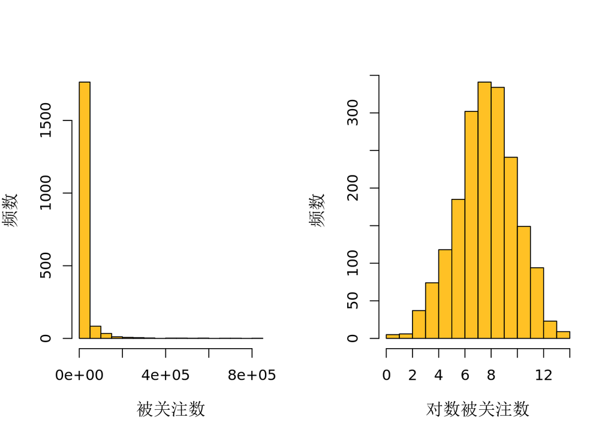

## 任务三

描述分析：分类型。 分类型变量包括：所在公司、职业、毕业院校。

#### 1.所在公司

在“公司”中，查看不同公司的出现次数，列出出现次数最多前20个公司。根据结果，我们将变量“公司”进行调整，将百度、阿里、腾讯三巨头统称为BAT，将其余的公司都归为“非BAT”。

```
##
##              腾讯      阿里巴巴集团              谷歌              百度
##                21                21                17                13
##              知乎          清华大学          Facebook        University
##                 9                 8                 6                 6
## 微软（Microsoft）      ThoughtWorks       (University          创业公司
##                 6                 5                 5                 5
##              网易          自由职业            NVIDIA          Research
##                 5                 5                 4                 4
##            互联网          北京大学          小米科技        律师事务所
##                 4                 4                 4                 4
```

使用箱线图查看是否是BAT与对数被关注数的关系

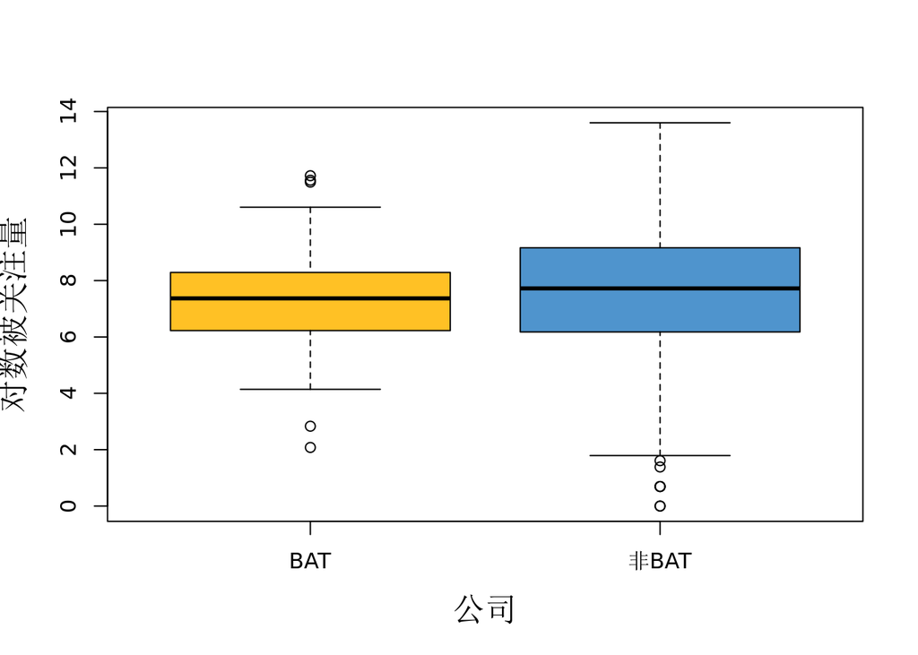

#### 2.职业

进一步地，我们对知乎用户进行职业分析。首先我们查看频率前20的职业，出现次数最多的就是“创始人”这个高大上的职业。

```
##
##      创始人         CEO  联合创始人    产品经理          of    (Google)
##         101          61          26          22          19          17
##  前端工程师      合伙人    产品总监      工程师         CTO    Software
##          15          15          12          12          11          11
##     Founder        打杂    Research (University        博士  软件工程师
##          10          10           9           9           9           9
##        主编  博士生在读
##           8           8
```

因此，我们将知乎用户职业划分为创始人（创始人、联合创始人、CEO、合伙人）与非创始人。进一步，使用箱线图查看是否是创始人与对数被关注数的关系，如果对箱线图进行解读？

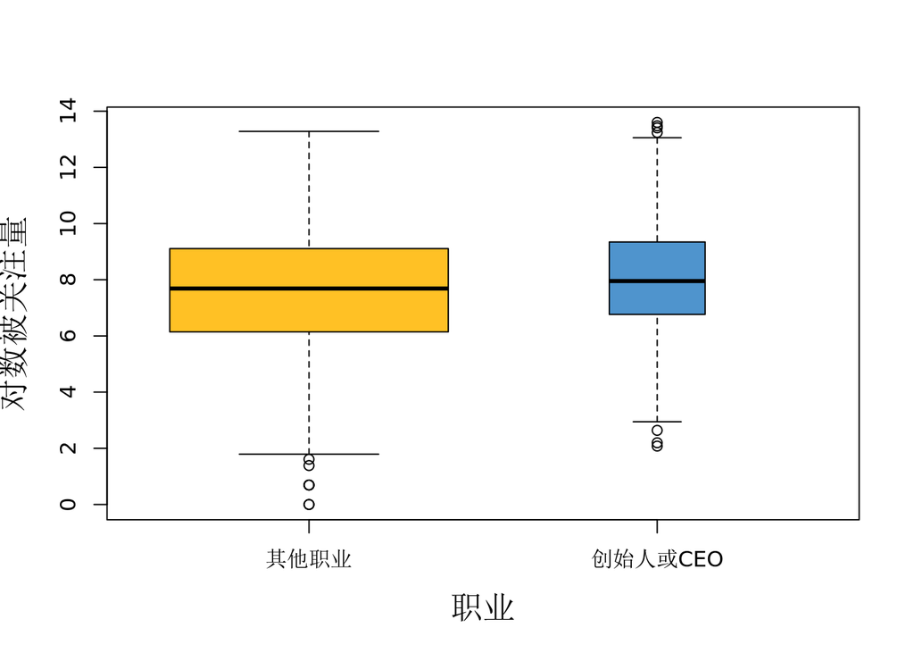

#### 3.毕业院校

一个人的毕业院校对于此人是否能够成为知乎大V很可能有影响。我们首先查看频率前20的毕业院校，根据数据的特点将毕业院校划分为：清北复交浙与非清北复交浙。

```
##
##            北京大学            清华大学            浙江大学
##                  65                  63                  42
##            复旦大学          University        上海交通大学
##                  37                  34                  26
##            南京大学        华中科技大学            同济大学
##                  21                  17                  17
##            武汉大学        中国传媒大学    中山大学（SYSU）
##                  17                  16                  16
##        中国人民大学        北京师范大学        哥伦比亚大学
##                  15                  15                  15
##    北京航空航天大学 北京理工大学（BIT）            南开大学
##                  14                  13                  13
##    中国科学技术大学      卡内基梅隆大学
##                  12                  12
```

使用箱线图查看毕业院校与对数被关注数的关系

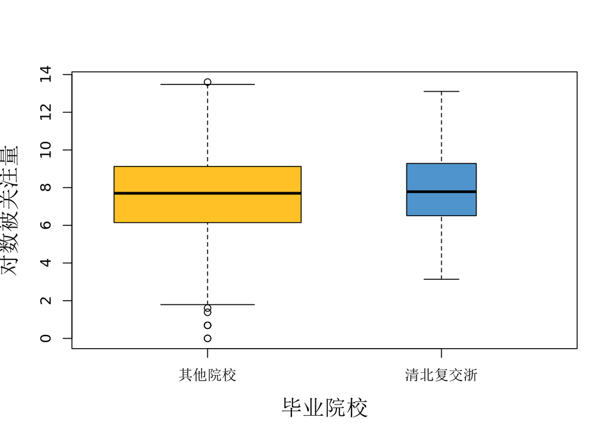

## 任务四

描述分析：连续型。以“提问数”为例进行分析 首先使用summary查看“提问数”的分布情况，找到其四分之三分位点，将提问数进行离散化处理，即小于四分之三分位点的为“低问”，否则为“高问”。然后使用箱线图查看不同提问情况与对数被关注数的关系，并尝试对箱线图进行解读

```
##    Min. 1st Qu.  Median    Mean 3rd Qu.    Max.
##    0.00    0.00    2.00   13.01    7.00 1754.00
```

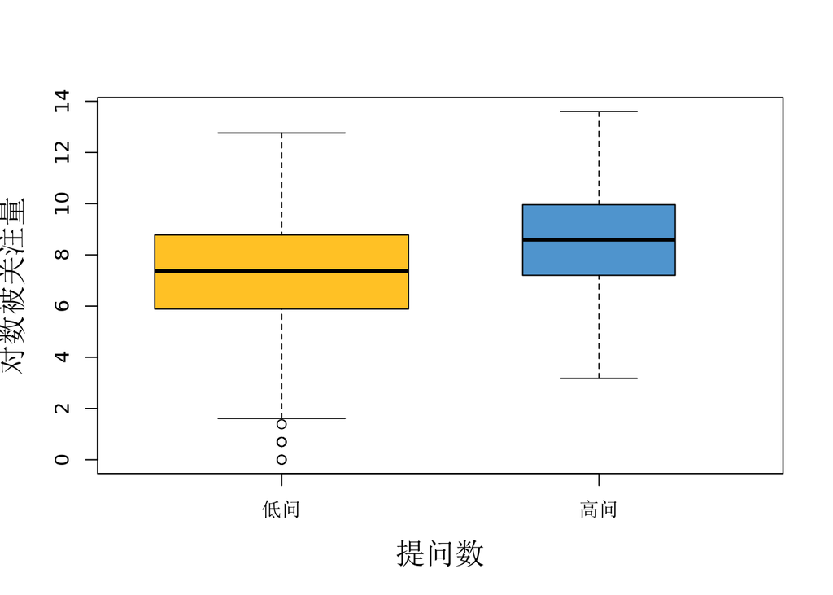

## 任务五

根据现有数据构造其他衍生自变量，包括：点赞回答比、感谢回答比、分享回答比。前三个变量可以通过将“点赞数”“感谢数”和“分享数”，分别除以回答数得到。进一步，对点赞回答比、感谢回答比、分享回答比三个变量按照100、10、0分别划分成高、低两个水进行，划分后的变量定义为“点赞比”“感谢比”和“分享比”。

## 任务六

回归分析。以“对数被关注数”为因变量，建立线性回归模型，并尝试进行解读。

```
##
## Call:
## lm(formula = log(被关注数) ~ 性别 + 公司 + 职业 + 毕业院校 +
##     提问数 + 专栏数 + 回答数 + 感谢比 + 点赞比 +
##     分享比, data = zhihu3)
##
## Residuals:
##      Min       1Q   Median       3Q      Max
## -10.1315  -0.9395   0.0555   1.0194   5.3865
##
## Coefficients:
##                      Estimate Std. Error t value Pr(>|t|)
## (Intercept)         5.453e+00  2.147e-01  25.400  < 2e-16 ***
## 性别               -2.983e-01  8.012e-02  -3.724 0.000202 ***
## 公司非BAT           1.785e-01  2.138e-01   0.835 0.404031
## 职业创始人或CEO     2.604e-01  1.164e-01   2.236 0.025473 *
## 毕业院校清北复交浙  3.848e-01  1.090e-01   3.530 0.000426 ***
## 提问数              1.491e-03  5.166e-04   2.886 0.003952 **
## 专栏数              5.358e-01  3.815e-02  14.044  < 2e-16 ***
## 回答数              7.878e-04  6.298e-05  12.509  < 2e-16 ***
## 感谢比高            1.611e+00  9.473e-02  17.009  < 2e-16 ***
## 点赞比高            9.554e-01  9.954e-02   9.598  < 2e-16 ***
## 分享比高            6.866e-01  7.981e-02   8.604  < 2e-16 ***
## ---
## Signif. codes:  0 '***' 0.001 '**' 0.01 '*' 0.05 '.' 0.1 ' ' 1
##
## Residual standard error: 1.555 on 1907 degrees of freedom
## Multiple R-squared:  0.519,  Adjusted R-squared:  0.5165
## F-statistic: 205.8 on 10 and 1907 DF,  p-value: < 2.2e-16
```